# PLS2 — Relación bacterias-metabolitos — Leonard et al. (2020)

2026-07-24

Este script relaciona bacterias (species) y metabolitos identificados como `EC_specific` en el análisis de LMM, mediante PLS2. Sigue el mismo plan acordado con la directora que en Leonard et al. (2021), aplicado a los dos modelos de este paper:

1. Selección de bacterias y metabolitos significativos en el LMM correspondiente.
2. PLS2 (X = bacterias, Y = metabolitos) con al menos 10 componentes.
3. Selección del número definitivo de componentes (revisando el gráfico R²/Q² por componente; **la elección final del número de componentes de cada modelo queda pendiente de decisión propia**, revisando los gráficos generados).
4. Gráficos de scores (coloreados por grupo, tiempo, país, sexo y modo de parto) y de loadings/weights, para identificar bacterias y metabolitos que actúan de forma coordinada.
5. Significación de las relaciones bacteria-metabolito mediante los coeficientes de regresión del PLS2, comparando jackknife, permutación y VIP.
6. Repetición del análisis por separado por subgrupo, para comprobar si la relación bacteria-metabolito cambia entre condiciones.
7. Representación de las relaciones significativas como grafos bipartitos (`ggraph`/`tidygraph`) y como heatmaps.

Se repite esta estructura una vez por modelo:

- **Modelo 1 (exposición ambiental)**: restringido a infantes genéticamente predispuestos (`Genetic_Risk_Group != "Negative"`), igual que en el LMM. El split por subgrupo es `Exposed` vs `Not exposed`.
- **Modelo 2 (riesgo genético)**: usa los 31 sujetos. El split por subgrupo es **`High` vs `Standard` vs `Negative`** — los 3 niveles de riesgo genético, tratados de forma simétrica (igual que en el LMM, donde `Standard` tiene el mismo peso que `High` en el criterio `EC_specific`). `High` (19 muestras) y `Negative` (14 muestras) tienen menos muestras que las 20 variables X; `Standard` (54 muestras) no. Confirmado con la directora que el objetivo de este análisis es **descriptivo, no predictivo**, por lo que esto no invalida el análisis en High/Negative — solo exige no interpretar su R²Y/Q² como medida de capacidad predictiva.

# Carga de librerías

```r
library(tidyverse)
library(PLSandO)
library(gridExtra)
library(igraph)
library(tidygraph)
library(ggraph)
library(here)

processed_dir <- here("data", "processed", "leonard_2020")
```

## Funciones auxiliares de visualización de relaciones

Se representan las relaciones bacteria-metabolito (permutación + VIP) como grafos bipartitos con `ggraph`/`tidygraph` (en vez de `igraph` base), porque reposiciona automáticamente las etiquetas para evitar solapes (`ggrepel`), igual que en los gráficos de loadings/weights del PLS.

```r
plot_bipartite_graph <- function(tabla, title, seed = 123) {
  edges <- tabla %>% select(bacteria, metabolito)

  g <- as_tbl_graph(graph_from_data_frame(edges, directed = FALSE)) %>%
    activate(nodes) %>%
    mutate(
      type = name %in% unique(tabla$bacteria),
      tipo = if_else(type, "Bacteria", "Metabolito")
    )

  set.seed(seed)
  ggraph(g, layout = "bipartite") +
    geom_edge_link(color = "grey70", alpha = 0.6) +
    geom_node_point(aes(color = tipo, shape = tipo), size = 5) +
    geom_node_text(aes(label = name), repel = TRUE, size = 3.3,
                    max.overlaps = Inf, seed = seed) +
    scale_color_manual(values = c("Bacteria" = "#3182bd", "Metabolito" = "#31a354")) +
    labs(title = title, color = NULL, shape = NULL) +
    theme_void() +
    theme(legend.position = "bottom", plot.title = element_text(hjust = 0.5))
}
```

Alternativa para cuando el grafo conjunto tiene demasiadas relaciones para leerse bien: dividir la tabla en bloques y graficar cada bloque por separado.

```r
plot_bipartite_graph_split <- function(tabla, title, block_size = 20, seed = 123) {
  n_blocks <- ceiling(nrow(tabla) / block_size)
  bloques <- split(tabla, ceiling(seq_len(nrow(tabla)) / block_size))

  imap(bloques, function(sub_tabla, i) {
    plot_bipartite_graph(sub_tabla, paste0(title, " (bloque ", i, "/", n_blocks, ")"), seed = seed)
  })
}
```

Alternativa: un panel pequeño por cada bacteria, mostrando solo sus metabolitos conectados.

```r
plot_star_by_bacteria <- function(tabla) {
  bacterias <- sort(unique(tabla$bacteria))

  plots <- map(bacterias, function(b) {
    sub_tabla <- tabla %>% filter(bacteria == b)
    edges <- sub_tabla %>% select(bacteria, metabolito)

    g <- as_tbl_graph(graph_from_data_frame(edges, directed = FALSE)) %>%
      activate(nodes) %>%
      mutate(
        type = name == b,
        tipo = if_else(type, "Bacteria", "Metabolito")
      )

    ggraph(g, layout = "star") +
      geom_edge_link(color = "grey70", alpha = 0.6) +
      geom_node_point(aes(color = tipo, shape = tipo), size = 5) +
      geom_node_text(aes(label = name), repel = TRUE, size = 4, max.overlaps = Inf) +
      scale_color_manual(values = c("Bacteria" = "#3182bd", "Metabolito" = "#31a354")) +
      labs(title = b) +
      theme_void() +
      theme(legend.position = "none", plot.title = element_text(size = 13, hjust = 0.5))
  })

  set_names(plots, bacterias)
}
```

Alternativa a los grafos que no sufre el problema de solape de etiquetas: una matriz bacteria×metabolito coloreada por el coeficiente de regresión del PLS.

```r
plot_heatmap_relaciones <- function(tabla, title) {
  ggplot(tabla, aes(x = metabolito, y = bacteria, fill = coeficiente)) +
    geom_tile(color = "grey30", linewidth = 0.6) +
    scale_fill_gradient2(low = "#08519c", mid = "white", high = "#a50f15",
                          midpoint = 0, name = "Coeficiente\nPLS") +
    scale_x_discrete(expand = c(0, 0)) +
    scale_y_discrete(expand = c(0, 0)) +
    labs(title = title, x = NULL, y = NULL,
         caption = "Celdas en gris: sin relación seleccionada mediante permutación") +
    theme_minimal() +
    theme(
      panel.grid = element_blank(),
      panel.background = element_rect(fill = "grey88", color = NA),
      axis.text.x = element_text(angle = 45, hjust = 1, size = 8, face = "bold"),
      axis.text.y = element_text(size = 9, face = "bold"),
      plot.title = element_text(hjust = 0.5),
      plot.caption = element_text(size = 8, hjust = 0, color = "grey40")
    )
}
```

# MODELO 1 — Exposición ambiental

## 1.1 Carga de datos y selección de variables EC-specific

```r
species_clr_data     <- readRDS(file.path(processed_dir, "species_clr_data.rds"))
metabolites_log_data <- readRDS(file.path(processed_dir, "metabolites_log_data.rds"))

species_model1_lmm_results     <- readRDS(file.path(processed_dir, "species_model1_lmm_results.rds"))
metabolites_model1_lmm_results <- readRDS(file.path(processed_dir, "metabolites_model1_lmm_results.rds"))

variables_species_model1     <- species_model1_lmm_results     %>% filter(EC_specific) %>% pull(variable)
variables_metabolites_model1 <- metabolites_model1_lmm_results %>% filter(EC_specific) %>% pull(variable)

cat("Species EC-specific (Modelo 1):    ", length(variables_species_model1), "\n")
```

```
## Species EC-specific (Modelo 1):     11
```

```r
cat("Metabolitos EC-specific (Modelo 1):", length(variables_metabolites_model1), "\n")
```

```
## Metabolitos EC-specific (Modelo 1): 11
```

## 1.2 Alineación de muestras (solo genéticamente predispuestos)

```r
species_key_model1 <- species_clr_data %>%
  filter(Genetic_Risk_Group != "Negative") %>%
  mutate(sample_key = paste(PaperID, time_point, sep = "_"))

metabolites_key_model1 <- metabolites_log_data %>%
  filter(Genetic_Risk_Group != "Negative") %>%
  mutate(sample_key = paste(PaperID, time_point, sep = "_"))

common_keys_model1 <- intersect(species_key_model1$sample_key, metabolites_key_model1$sample_key)

cat("Muestras species:     ", nrow(species_key_model1), "\n")
```

```
## Muestras species:      73
```

```r
cat("Muestras metabolitos: ", nrow(metabolites_key_model1), "\n")
```

```
## Muestras metabolitos:  73
```

```r
cat("Muestras comunes:     ", length(common_keys_model1), "\n")
```

```
## Muestras comunes:      73
```

```r
species_aligned_model1     <- species_key_model1     %>% filter(sample_key %in% common_keys_model1) %>% arrange(sample_key)
metabolites_aligned_model1 <- metabolites_key_model1 %>% filter(sample_key %in% common_keys_model1) %>% arrange(sample_key)

identical(species_aligned_model1$sample_key, metabolites_aligned_model1$sample_key)
```

```
## [1] TRUE
```

```r
setdiff(species_key_model1$sample_key, metabolites_key_model1$sample_key)
```

```
## character(0)
```

```r
setdiff(metabolites_key_model1$sample_key, species_key_model1$sample_key)
```

```
## character(0)
```

## 1.3 Construcción de las matrices X (species) e Y (metabolitos)

```r
X_model1 <- species_aligned_model1     %>% select(all_of(variables_species_model1))     %>% as.data.frame()
Y_model1 <- metabolites_aligned_model1 %>% select(all_of(variables_metabolites_model1)) %>% as.data.frame()

rownames(X_model1) <- species_aligned_model1$sample_key
rownames(Y_model1) <- metabolites_aligned_model1$sample_key

cat("Filas X:", nrow(X_model1), "| Columnas X:", ncol(X_model1), "\n")
```

```
## Filas X: 73 | Columnas X: 11
```

```r
cat("Filas Y:", nrow(Y_model1), "| Columnas Y:", ncol(Y_model1), "\n")
```

```
## Filas Y: 73 | Columnas Y: 11
```

## 1.4 PLS2 — modelo conjunto (todas las muestras)

### 1.4.1 Selección del número de componentes

```r
set.seed(123)

modelo1_pls2 <- pls(
  x        = X_model1,
  y        = Y_model1,
  ncomp    = 10,
  cvFolds  = 5,
  rep      = 10,
  perm     = 100,
  scaling  = "standard",
  scalingY = "standard",
  algo     = "nipals",
  train    = 1,
  parallel = FALSE
)
```

[output not shown]

[output not shown]

```r
modelo1_pls2$summary
```

```
##    comp        R2X    cumR2X         R2Y     cumR2Y           Q2       cumQ2
## 1     1 0.24068941 0.2406894 0.034637225 0.03463723 -0.029372021 -0.02937202
## 2     2 0.11076327 0.3514527 0.040502243 0.07513947 -0.023112965 -0.05248499
## 3     3 0.08620907 0.4376617 0.038501608 0.11364108 -0.041924666 -0.09440965
## 4     4 0.13222004 0.5698818 0.013765830 0.12740691 -0.006657402 -0.10106705
## 5     5 0.08988288 0.6597647 0.012620963 0.14002787 -0.024610685 -0.12567774
## 6     6 0.06880165 0.7285663 0.007933021 0.14796089 -0.024600175 -0.15027791
## 7     7 0.04872767 0.7772940 0.006104041 0.15406493 -0.026896549 -0.17717446
## 8     8 0.07549699 0.8527910 0.003491002 0.15755593 -0.016748309 -0.19392277
## 9     9 0.06325354 0.9160445 0.002078127 0.15963406 -0.013522558 -0.20744533
## 10   10 0.03613885 0.9521834 0.001603444 0.16123750 -0.013214242 -0.22065957
##        RMSE
## 1  1.007599
## 2  1.018815
## 3  1.038906
## 4  1.042058
## 5  1.053576
## 6  1.065019
## 7  1.077416
## 8  1.085070
## 9  1.091191
## 10 1.097146
```

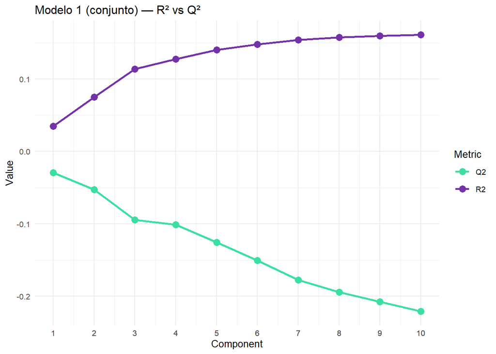

```r
plsPlot(modelo1_pls2, type = "R2vsQ2") +
  ggtitle("Modelo 1 (conjunto) — R² vs Q²")
```

**Revisar el gráfico anterior y fijar aquí el número definitivo de componentes** (criterio: codo en el R²Y individual por componente; el Q² no se usa como criterio de decisión, solo como referencia).

```r
ncomp_model1 <- 3

set.seed(123)

modelo1_pls2 <- pls(
  x        = X_model1,
  y        = Y_model1,
  ncomp    = ncomp_model1,
  cvFolds  = 5,
  rep      = 10,
  perm     = 100,
  scaling  = "standard",
  scalingY = "standard",
  algo     = "nipals",
  train    = 1,
  parallel = FALSE
)
```

[output not shown]

[output not shown]

```r
modelo1_pls2$summary
```

```
##   comp        R2X    cumR2X        R2Y     cumR2Y          Q2       cumQ2
## 1    1 0.24068941 0.2406894 0.03463723 0.03463723 -0.02937202 -0.02937202
## 2    2 0.11076327 0.3514527 0.04050224 0.07513947 -0.02311297 -0.05248499
## 3    3 0.08620907 0.4376617 0.03850161 0.11364108 -0.04192467 -0.09440965
##       RMSE
## 1 1.007599
## 2 1.018815
## 3 1.038906
```

### 1.4.2 Gráficos de scores

```r
covar_exposure_model1 <- data.frame(Exposicion = species_aligned_model1$Exposure_to_Environmental_Factors)
covar_time_model1     <- factor(species_aligned_model1$time_point,
                                 levels = c("Enrollment", "3_months", "4_6_months"))
covar_country_model1  <- data.frame(Country = species_aligned_model1$country)
covar_gender_model1   <- data.frame(Gender = species_aligned_model1$Gender)
covar_deliv_model1    <- data.frame(Delivery = species_aligned_model1$Delivery_Mode)
```

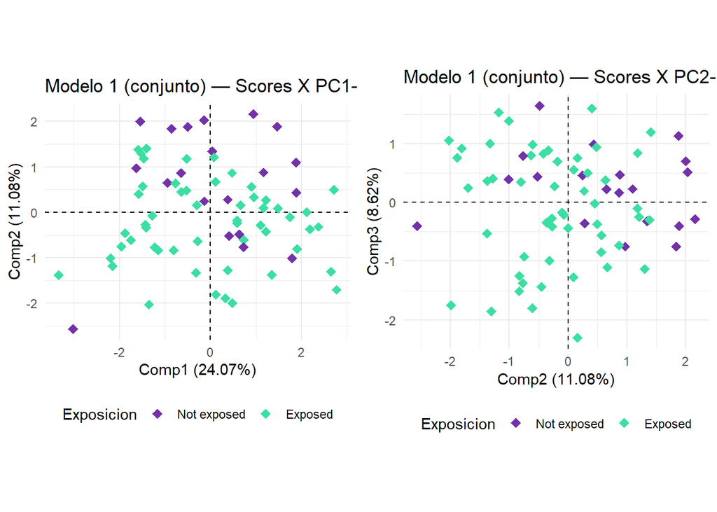

```r
p1_exp_model1  <- plsPlot(modelo1_pls2, type = "scoresX", comp = 1:2, colBy = covar_exposure_model1, labels = FALSE, ellipses = FALSE) +
  ggtitle("Modelo 1 (conjunto) — Scores X PC1-PC2 por exposición ambiental")
p11_exp_model1 <- plsPlot(modelo1_pls2, type = "scoresX", comp = 2:3, colBy = covar_exposure_model1, labels = FALSE, ellipses = FALSE) +
  ggtitle("Modelo 1 (conjunto) — Scores X PC2-PC3 por exposición ambiental")
grid.arrange(p1_exp_model1, p11_exp_model1, ncol = 2)
```

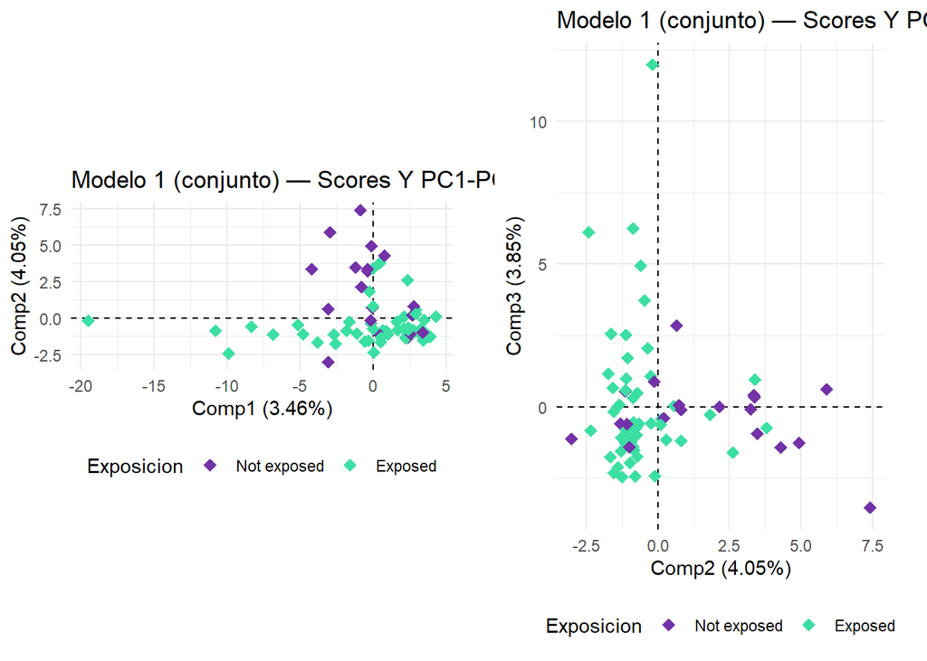

```r
p2_exp_model1  <- plsPlot(modelo1_pls2, type = "scoresY", comp = 1:2, colBy = covar_exposure_model1, labels = FALSE, ellipses = FALSE) +
  ggtitle("Modelo 1 (conjunto) — Scores Y PC1-PC2 por exposición ambiental")
p21_exp_model1 <- plsPlot(modelo1_pls2, type = "scoresY", comp = 2:3, colBy = covar_exposure_model1, labels = FALSE, ellipses = FALSE) +
  ggtitle("Modelo 1 (conjunto) — Scores Y PC2-PC3 por exposición ambiental")
grid.arrange(p2_exp_model1, p21_exp_model1, ncol = 2)
```

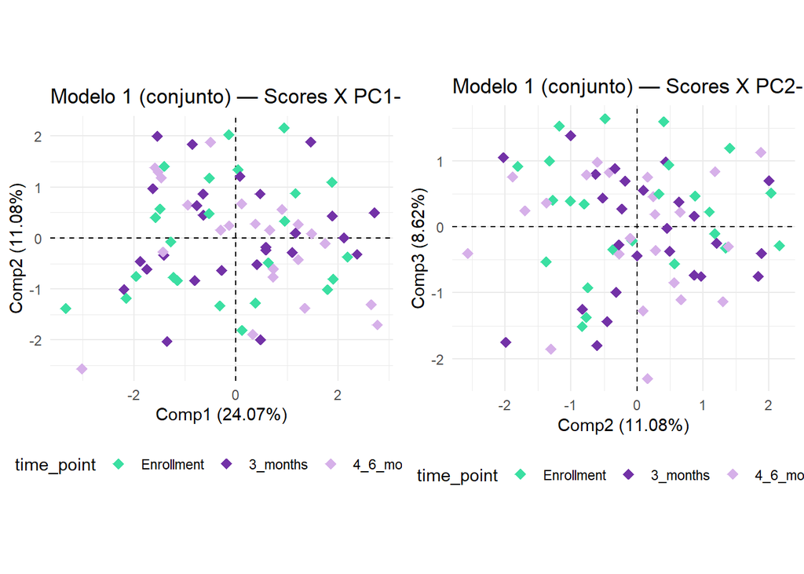

```r
p1_time_model1  <- plsPlot(modelo1_pls2, type = "scoresX", comp = 1:2,
                            colBy = data.frame(time_point = covar_time_model1), labels = FALSE, ellipses = FALSE) +
  ggtitle("Modelo 1 (conjunto) — Scores X PC1-PC2 por tiempo")
p11_time_model1 <- plsPlot(modelo1_pls2, type = "scoresX", comp = 2:3,
                            colBy = data.frame(time_point = covar_time_model1), labels = FALSE, ellipses = FALSE) +
  ggtitle("Modelo 1 (conjunto) — Scores X PC2-PC3 por tiempo")
grid.arrange(p1_time_model1, p11_time_model1, ncol = 2)
```

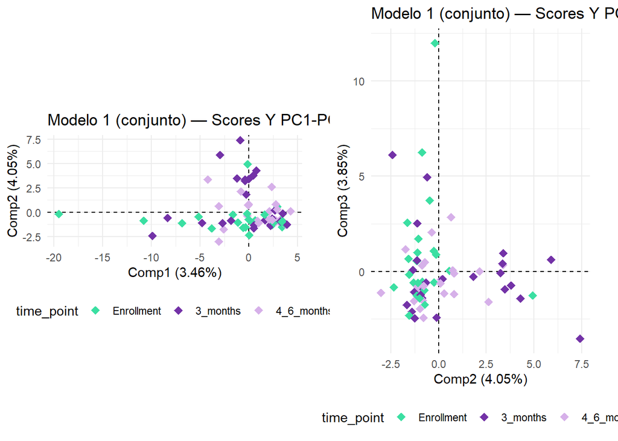

```r
p2_time_model1  <- plsPlot(modelo1_pls2, type = "scoresY", comp = 1:2,
                            colBy = data.frame(time_point = covar_time_model1), labels = FALSE, ellipses = FALSE) +
  ggtitle("Modelo 1 (conjunto) — Scores Y PC1-PC2 por tiempo")
p21_time_model1 <- plsPlot(modelo1_pls2, type = "scoresY", comp = 2:3,
                            colBy = data.frame(time_point = covar_time_model1), labels = FALSE, ellipses = FALSE) +
  ggtitle("Modelo 1 (conjunto) — Scores Y PC2-PC3 por tiempo")
grid.arrange(p2_time_model1, p21_time_model1, ncol = 2)
```

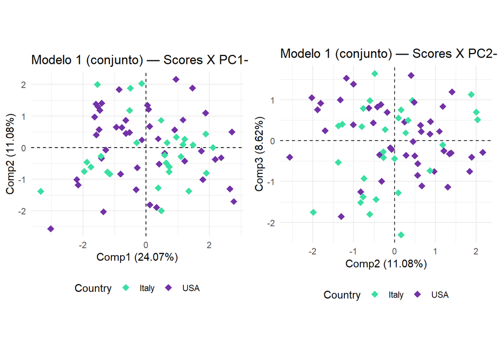

```r
p1_country_model1  <- plsPlot(modelo1_pls2, type = "scoresX", comp = 1:2, colBy = covar_country_model1, labels = FALSE, ellipses = FALSE) +
  ggtitle("Modelo 1 (conjunto) — Scores X PC1-PC2 por país")
p11_country_model1 <- plsPlot(modelo1_pls2, type = "scoresX", comp = 2:3, colBy = covar_country_model1, labels = FALSE, ellipses = FALSE) +
  ggtitle("Modelo 1 (conjunto) — Scores X PC2-PC3 por país")
grid.arrange(p1_country_model1, p11_country_model1, ncol = 2)
```

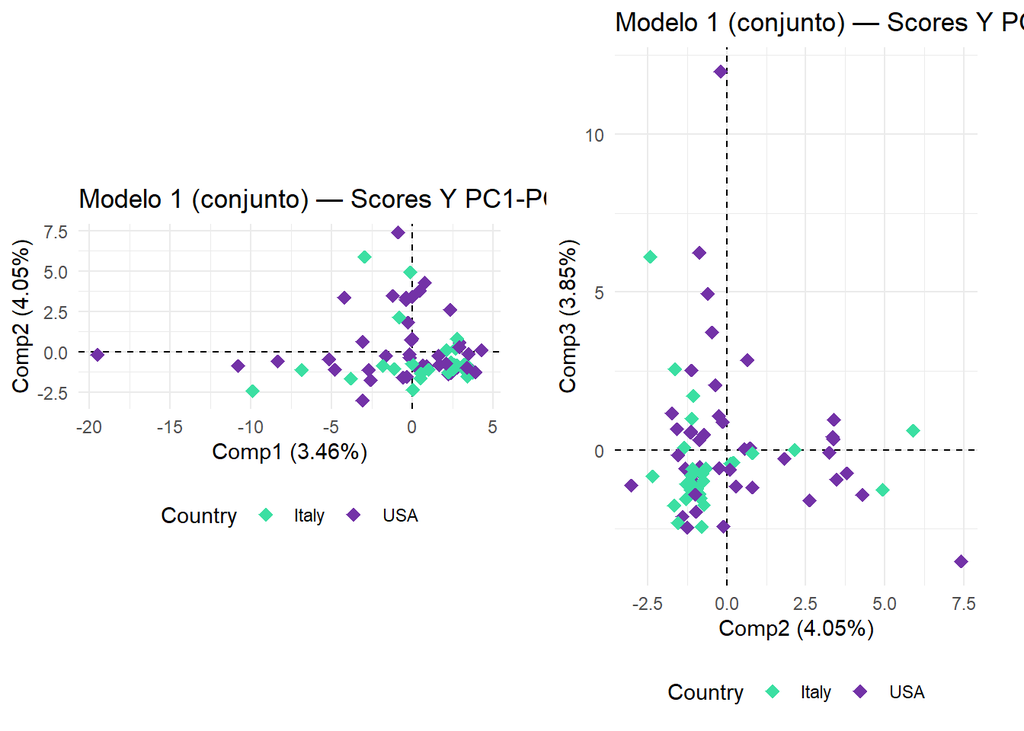

```r
p2_country_model1  <- plsPlot(modelo1_pls2, type = "scoresY", comp = 1:2, colBy = covar_country_model1, labels = FALSE, ellipses = FALSE) +
  ggtitle("Modelo 1 (conjunto) — Scores Y PC1-PC2 por país")
p21_country_model1 <- plsPlot(modelo1_pls2, type = "scoresY", comp = 2:3, colBy = covar_country_model1, labels = FALSE, ellipses = FALSE) +
  ggtitle("Modelo 1 (conjunto) — Scores Y PC2-PC3 por país")
grid.arrange(p2_country_model1, p21_country_model1, ncol = 2)
```

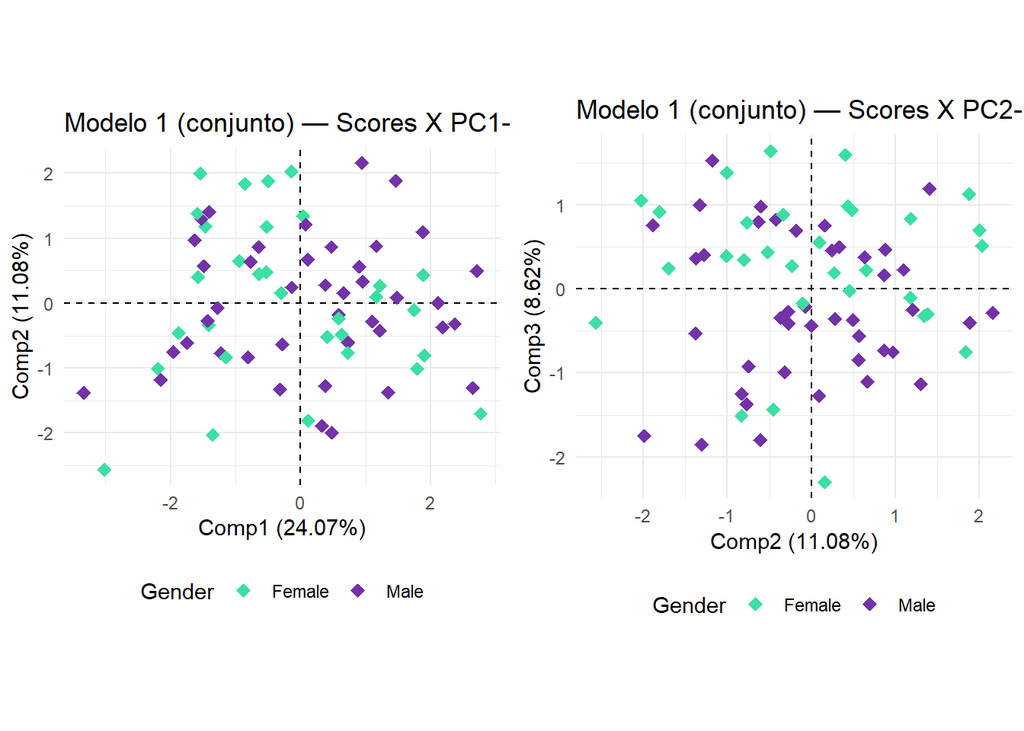

```r
p1_gender_model1  <- plsPlot(modelo1_pls2, type = "scoresX", comp = 1:2, colBy = covar_gender_model1, labels = FALSE, ellipses = FALSE) +
  ggtitle("Modelo 1 (conjunto) — Scores X PC1-PC2 por sexo")
p11_gender_model1 <- plsPlot(modelo1_pls2, type = "scoresX", comp = 2:3, colBy = covar_gender_model1, labels = FALSE, ellipses = FALSE) +
  ggtitle("Modelo 1 (conjunto) — Scores X PC2-PC3 por sexo")
grid.arrange(p1_gender_model1, p11_gender_model1, ncol = 2)
```

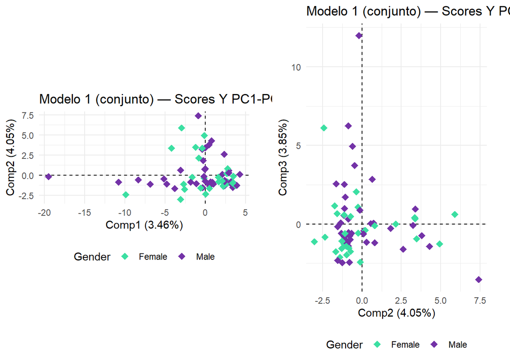

```r
p2_gender_model1  <- plsPlot(modelo1_pls2, type = "scoresY", comp = 1:2, colBy = covar_gender_model1, labels = FALSE, ellipses = FALSE) +
  ggtitle("Modelo 1 (conjunto) — Scores Y PC1-PC2 por sexo")
p21_gender_model1 <- plsPlot(modelo1_pls2, type = "scoresY", comp = 2:3, colBy = covar_gender_model1, labels = FALSE, ellipses = FALSE) +
  ggtitle("Modelo 1 (conjunto) — Scores Y PC2-PC3 por sexo")
grid.arrange(p2_gender_model1, p21_gender_model1, ncol = 2)
```

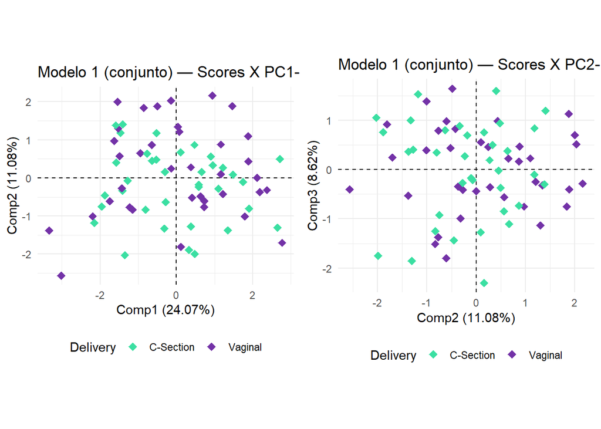

```r
p1_deliv_model1  <- plsPlot(modelo1_pls2, type = "scoresX", comp = 1:2, colBy = covar_deliv_model1, labels = FALSE, ellipses = FALSE) +
  ggtitle("Modelo 1 (conjunto) — Scores X PC1-PC2 por tipo de parto")
p11_deliv_model1 <- plsPlot(modelo1_pls2, type = "scoresX", comp = 2:3, colBy = covar_deliv_model1, labels = FALSE, ellipses = FALSE) +
  ggtitle("Modelo 1 (conjunto) — Scores X PC2-PC3 por tipo de parto")
grid.arrange(p1_deliv_model1, p11_deliv_model1, ncol = 2)
```

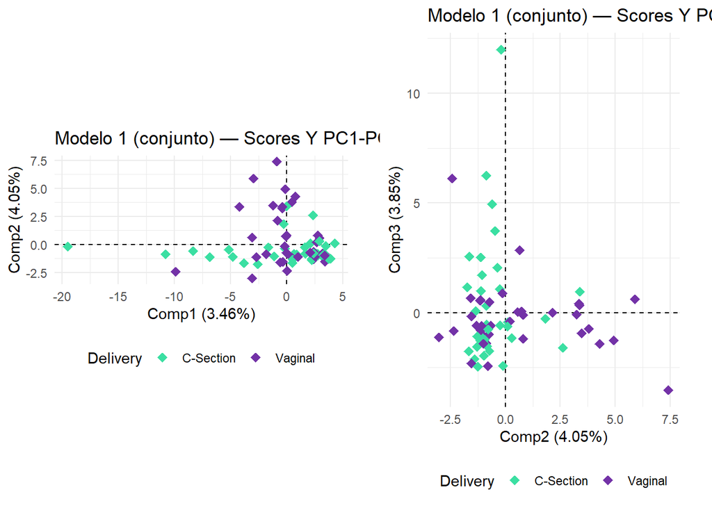

```r
p2_deliv_model1  <- plsPlot(modelo1_pls2, type = "scoresY", comp = 1:2, colBy = covar_deliv_model1, labels = FALSE, ellipses = FALSE) +
  ggtitle("Modelo 1 (conjunto) — Scores Y PC1-PC2 por tipo de parto")
p21_deliv_model1 <- plsPlot(modelo1_pls2, type = "scoresY", comp = 2:3, colBy = covar_deliv_model1, labels = FALSE, ellipses = FALSE) +
  ggtitle("Modelo 1 (conjunto) — Scores Y PC2-PC3 por tipo de parto")
grid.arrange(p2_deliv_model1, p21_deliv_model1, ncol = 2)
```

### 1.4.3 Gráficos de loadings

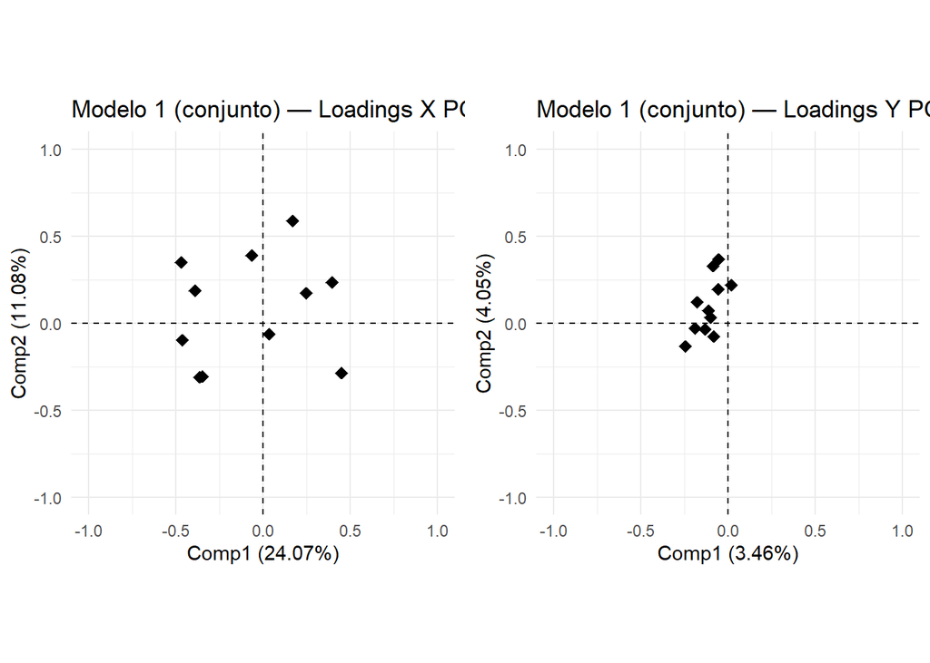

```r
p_loadX_model1  <- plsPlot(modelo1_pls2, type = "loadingsX", comp = 1:2, shape = "point", labels = FALSE, repel = TRUE) +
  ggtitle("Modelo 1 (conjunto) — Loadings X PC1-PC2")
p_loadY_model1  <- plsPlot(modelo1_pls2, type = "loadingsY", comp = 1:2, shape = "point", labels = FALSE, repel = TRUE) +
  ggtitle("Modelo 1 (conjunto) — Loadings Y PC1-PC2")
grid.arrange(p_loadX_model1, p_loadY_model1, ncol = 2)
```

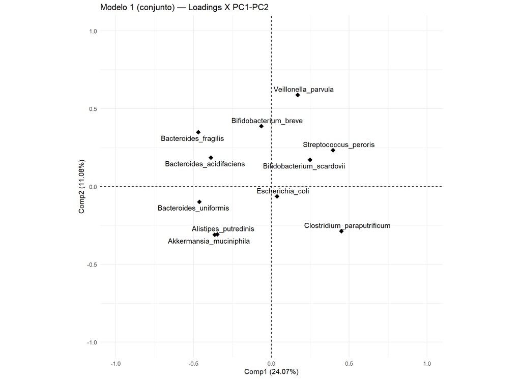

```r
plsPlot(modelo1_pls2, type = "loadingsX", comp = 1:2, shape = "point", labels = TRUE, repel = TRUE) +
  ggtitle("Modelo 1 (conjunto) — Loadings X PC1-PC2")
```

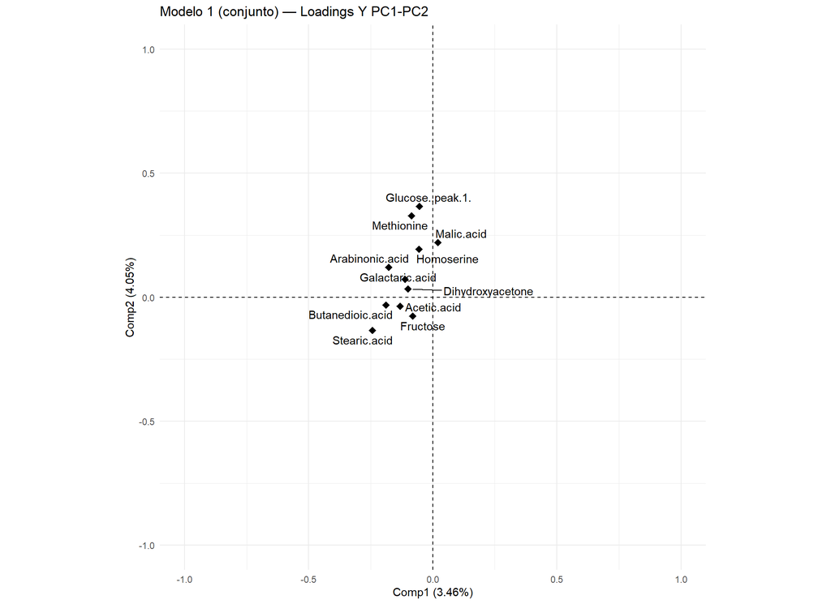

```r
plsPlot(modelo1_pls2, type = "loadingsY", comp = 1:2, shape = "point", labels = TRUE, repel = TRUE) +
  ggtitle("Modelo 1 (conjunto) — Loadings Y PC1-PC2")
```

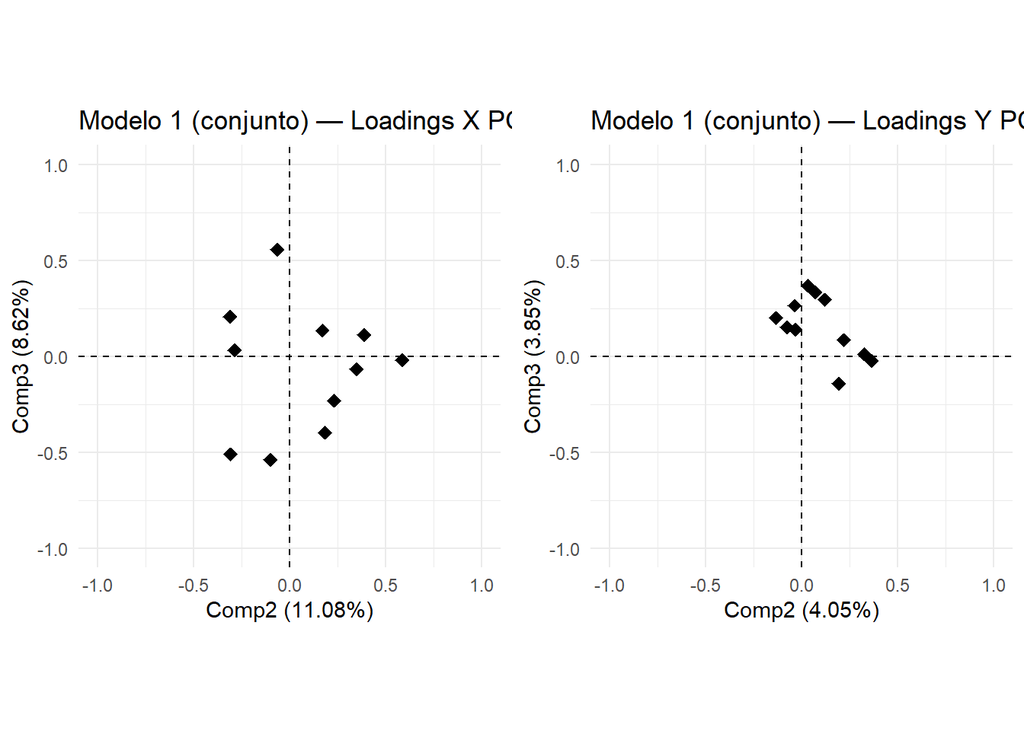

```r
p_loadX1_model1 <- plsPlot(modelo1_pls2, type = "loadingsX", comp = 2:3, shape = "point", labels = FALSE, repel = TRUE) +
  ggtitle("Modelo 1 (conjunto) — Loadings X PC2-PC3")
p_loadY1_model1 <- plsPlot(modelo1_pls2, type = "loadingsY", comp = 2:3, shape = "point", labels = FALSE, repel = TRUE) +
  ggtitle("Modelo 1 (conjunto) — Loadings Y PC2-PC3")
grid.arrange(p_loadX1_model1, p_loadY1_model1, ncol = 2)
```

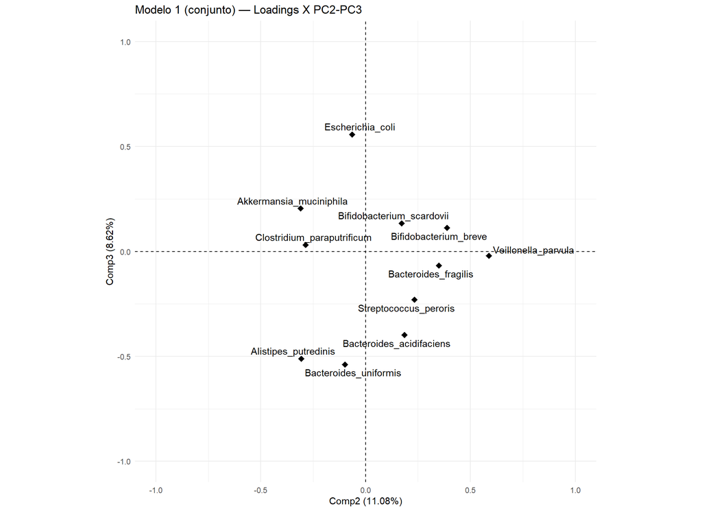

```r
plsPlot(modelo1_pls2, type = "loadingsX", comp = 2:3, shape = "point", labels = TRUE, repel = TRUE) +
  ggtitle("Modelo 1 (conjunto) — Loadings X PC2-PC3")
```

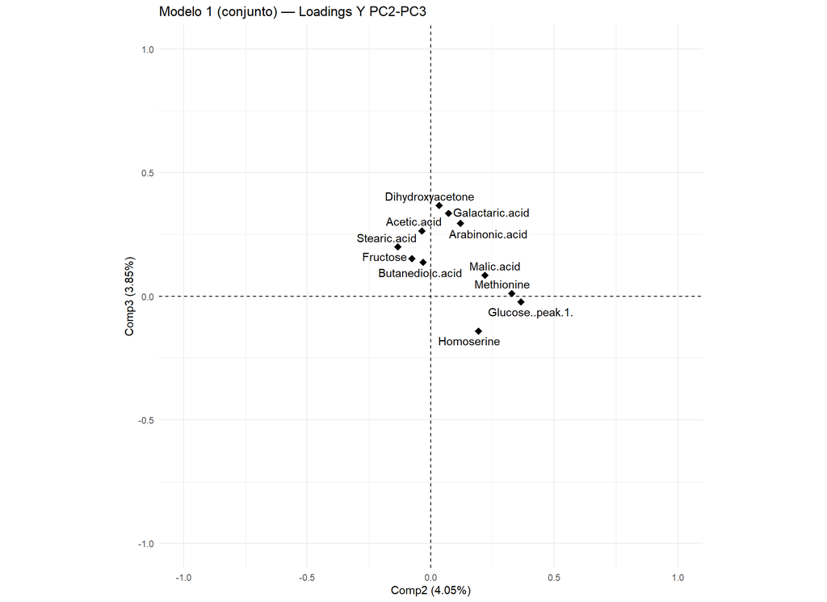

```r
plsPlot(modelo1_pls2, type = "loadingsY", comp = 2:3, shape = "point", labels = TRUE, repel = TRUE) +
  ggtitle("Modelo 1 (conjunto) — Loadings Y PC2-PC3")
```

### 1.4.4 Gráfico de weights

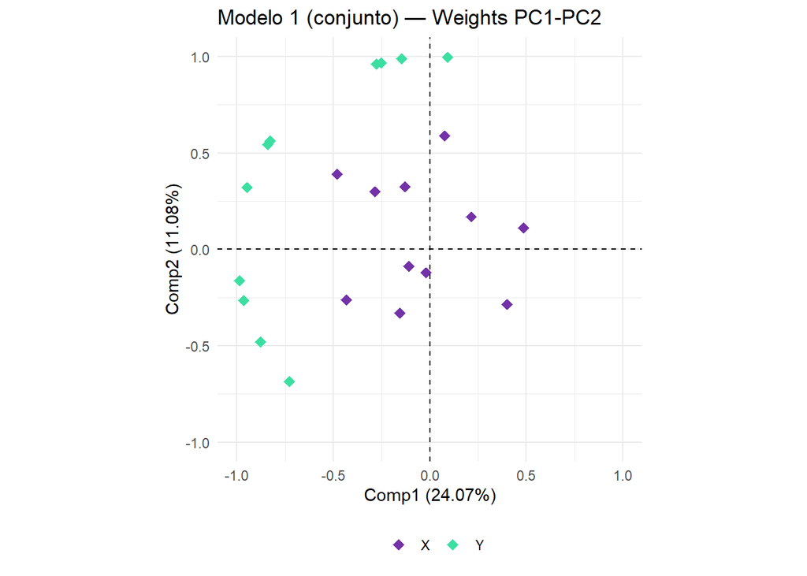

```r
plsPlot(modelo1_pls2, type = "weights", comp = 1:2, shape = "point", labels = FALSE, repel = TRUE) +
  ggtitle("Modelo 1 (conjunto) — Weights PC1-PC2")
```

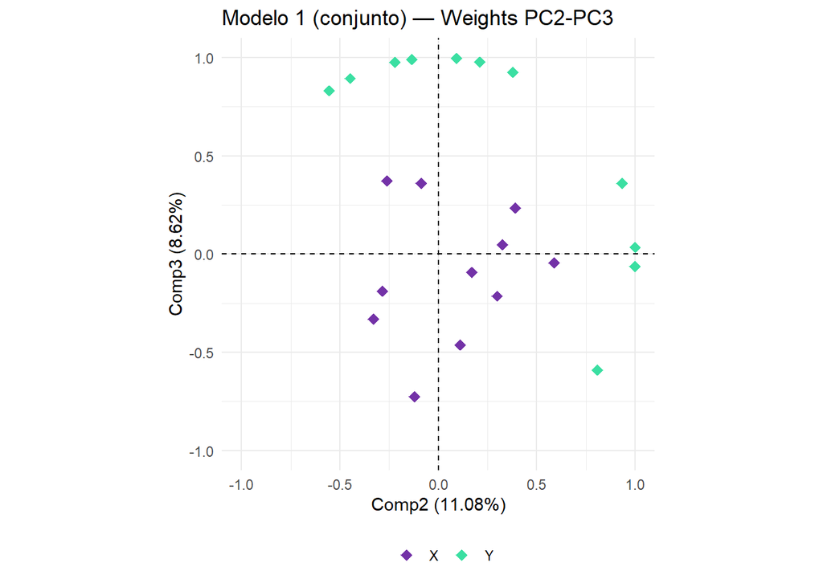

```r
plsPlot(modelo1_pls2, type = "weights", comp = 2:3, shape = "point", labels = FALSE, repel = TRUE) +
  ggtitle("Modelo 1 (conjunto) — Weights PC2-PC3")
```

Versión con etiquetas :

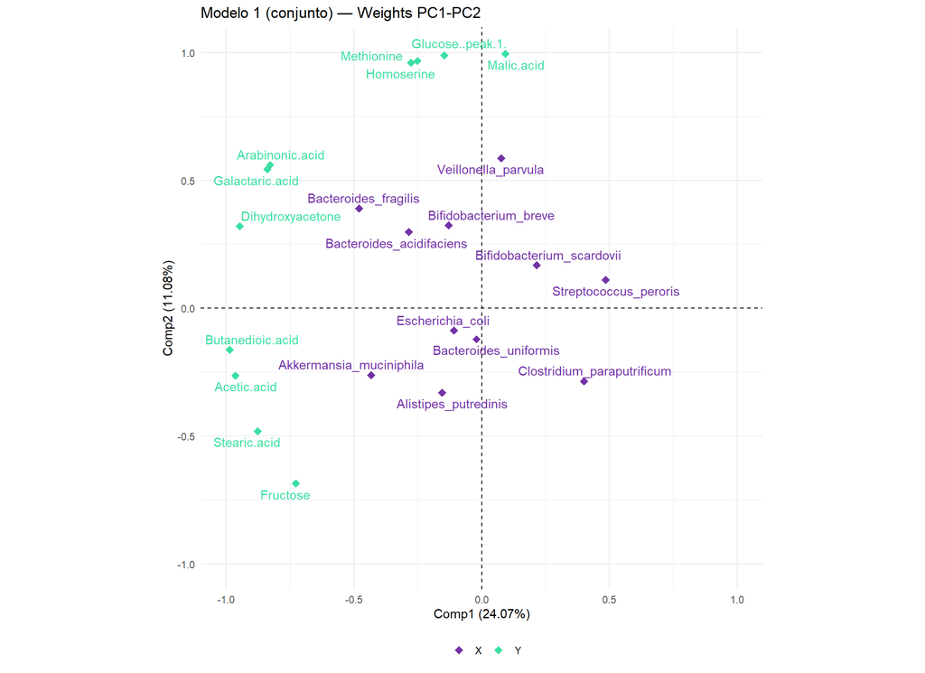

```r
plsPlot(modelo1_pls2, type = "weights", comp = 1:2,shape = "point", labels = TRUE, repel = TRUE) +
  ggtitle("Modelo 1 (conjunto) — Weights PC1-PC2")
```

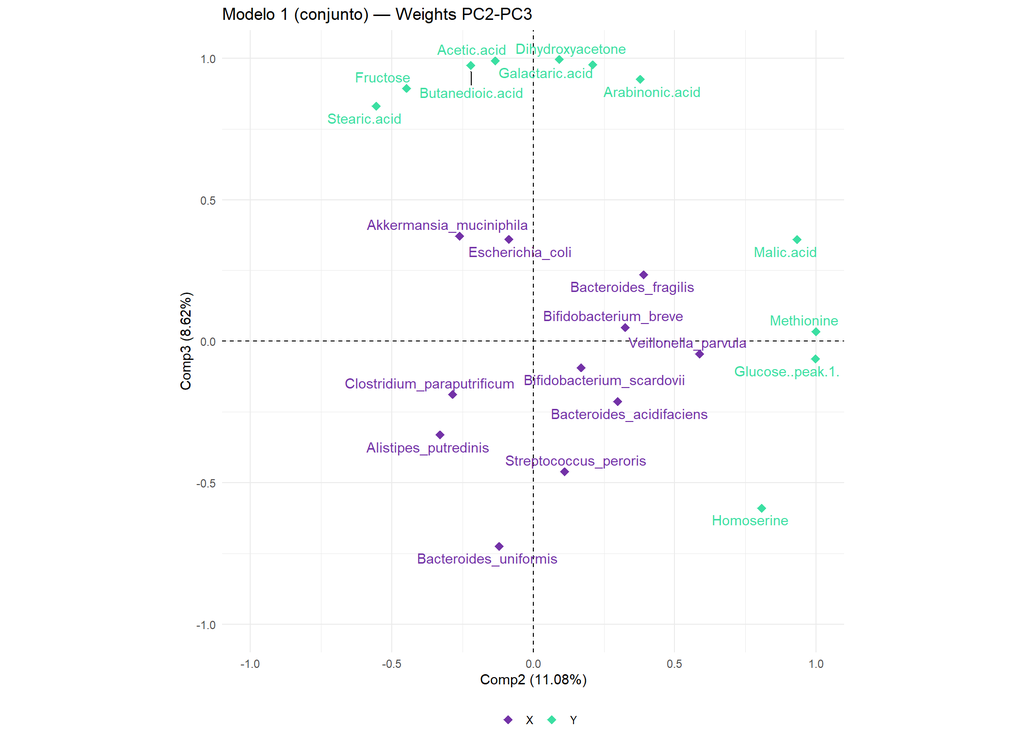

```r
plsPlot(modelo1_pls2, type = "weights", comp = 2:3, shape = "point", labels = TRUE, repel = TRUE) +
  ggtitle("Modelo 1 (conjunto) — Weights PC2-PC3")
```

### 1.4.5 Significación de las relaciones bacteria-metabolito

```r
set.seed(123)

jack_model1 <- plsVarSel(modelo1_pls2, type = "Jack", rep = 100, threshold = 0.05)
```

```r
perm_model1 <- plsVarSel(modelo1_pls2, type = "Perm", rep = 1000, threshold = 0.05)
```

```r
vip_model1  <- plsVarSel(modelo1_pls2, type = "VIP")
```

```r
cat("Metabolitos con alguna bacteria significativa (Jack):", sum(sapply(jack_model1, nrow) > 0), "\n")
```

```
## Metabolitos con alguna bacteria significativa (Jack): 0
```

```r
cat("Metabolitos con alguna bacteria significativa (Perm):", sum(sapply(perm_model1, nrow) > 0), "\n")
```

```
## Metabolitos con alguna bacteria significativa (Perm): 7
```

```r
cat("Relaciones totales (Jack):", sum(sapply(jack_model1, nrow)), "\n")
```

```
## Relaciones totales (Jack): 0
```

```r
cat("Relaciones totales (Perm):", sum(sapply(perm_model1, nrow)), "\n")
```

```
## Relaciones totales (Perm): 15
```

```r
cat("Bacterias con VIP > 1:", nrow(vip_model1), "\n")
```

```
## Bacterias con VIP > 1: 7
```

```r
bacterias_perm_model1 <- perm_model1 %>%
  discard(~ nrow(.x) == 0) %>%
  map(rownames) %>%
  unlist() %>%
  unique()

intersect(rownames(vip_model1), bacterias_perm_model1)
```

```
## [1] "Bacteroides_uniformis"   "Veillonella_parvula"
## [3] "Bacteroides_fragilis"    "Akkermansia_muciniphila"
## [5] "Streptococcus_peroris"
```

```r
perm_no_vacios_model1 <- perm_model1[sapply(perm_model1, nrow) > 0]

tabla_relaciones_model1 <- perm_no_vacios_model1 %>%
  imap_dfr(~ tibble(
    metabolito = .y,
    bacteria   = rownames(.x),
    p_perm     = .x$pValPerm
  )) %>%
  mutate(en_VIP = bacteria %in% rownames(vip_model1)) %>%
  mutate(coeficiente = modelo1_pls2$coefficients[cbind(bacteria, metabolito)]) %>%
  arrange(metabolito, p_perm)

tabla_relaciones_model1
```

```
## # A tibble: 15 × 5
##    metabolito       bacteria                p_perm en_VIP coeficiente
##    <chr>            <chr>                    <dbl> <lgl>        <dbl>
##  1 Acetic.acid      Bacteroides_uniformis    0.046 TRUE        -0.185
##  2 Acetic.acid      Streptococcus_peroris    0.046 TRUE        -0.189
##  3 Arabinonic.acid  Bacteroides_uniformis    0.016 TRUE        -0.224
##  4 Arabinonic.acid  Streptococcus_peroris    0.028 TRUE        -0.208
##  5 Arabinonic.acid  Bacteroides_fragilis     0.044 TRUE         0.201
##  6 Dihydroxyacetone Bacteroides_uniformis    0.01  TRUE        -0.269
##  7 Dihydroxyacetone Streptococcus_peroris    0.032 TRUE        -0.214
##  8 Galactaric.acid  Bacteroides_uniformis    0.007 TRUE        -0.250
##  9 Galactaric.acid  Streptococcus_peroris    0.023 TRUE        -0.201
## 10 Galactaric.acid  Bacteroides_fragilis     0.047 TRUE         0.160
## 11 Glucose..peak.1. Veillonella_parvula      0.026 TRUE         0.212
## 12 Methionine       Bacteroides_fragilis     0.029 TRUE         0.172
## 13 Methionine       Veillonella_parvula      0.045 TRUE         0.186
## 14 Stearic.acid     Streptococcus_peroris    0.023 TRUE        -0.225
## 15 Stearic.acid     Akkermansia_muciniphila  0.038 TRUE         0.214
```

```r
write_csv(tabla_relaciones_model1, file.path(processed_dir, "relaciones_bacteria_metabolito_model1_perm.csv"))
```

## 1.5 PLS2 separado por subgrupo (Expuesto vs. No expuesto)

Se repite el análisis completo por separado para expuestos y no-expuestos, para comprobar si la relación bacteria-metabolito cambia entre condiciones — esperable, ya que las variables de entrada se seleccionaron precisamente por su asociación con la exposición ambiental en el LMM.

### 1.5.1 División de las muestras por subgrupo

```r
species_exposed_model1     <- species_aligned_model1     %>% filter(Exposure_to_Environmental_Factors == "Exposed")
species_notexposed_model1  <- species_aligned_model1     %>% filter(Exposure_to_Environmental_Factors == "Not exposed")

metabolites_exposed_model1    <- metabolites_aligned_model1 %>% filter(Exposure_to_Environmental_Factors == "Exposed")
metabolites_notexposed_model1 <- metabolites_aligned_model1 %>% filter(Exposure_to_Environmental_Factors == "Not exposed")

cat("Muestras Expuestos:    ", nrow(species_exposed_model1), "\n")
```

```
## Muestras Expuestos:     53
```

```r
cat("Muestras No expuestos: ", nrow(species_notexposed_model1), "\n")
```

```
## Muestras No expuestos:  20
```

```r
identical(species_exposed_model1$sample_key, metabolites_exposed_model1$sample_key)
```

```
## [1] TRUE
```

```r
identical(species_notexposed_model1$sample_key, metabolites_notexposed_model1$sample_key)
```

```
## [1] TRUE
```

```r
X_exposed_model1 <- species_exposed_model1 %>% select(all_of(variables_species_model1)) %>% as.data.frame()
Y_exposed_model1 <- metabolites_exposed_model1 %>% select(all_of(variables_metabolites_model1)) %>% as.data.frame()
rownames(X_exposed_model1) <- species_exposed_model1$sample_key
rownames(Y_exposed_model1) <- metabolites_exposed_model1$sample_key

X_notexposed_model1 <- species_notexposed_model1 %>% select(all_of(variables_species_model1)) %>% as.data.frame()
Y_notexposed_model1 <- metabolites_notexposed_model1 %>% select(all_of(variables_metabolites_model1)) %>% as.data.frame()
rownames(X_notexposed_model1) <- species_notexposed_model1$sample_key
rownames(Y_notexposed_model1) <- metabolites_notexposed_model1$sample_key

cat("Expuestos:    X", dim(X_exposed_model1), " Y", dim(Y_exposed_model1), "\n")
```

```
## Expuestos:    X 53 11  Y 53 11
```

```r
cat("No expuestos: X", dim(X_notexposed_model1), " Y", dim(Y_notexposed_model1), "\n")
```

```
## No expuestos: X 20 11  Y 20 11
```

### 1.5.2 Selección del número de componentes (por subgrupo)

#### Ajuste exploratorio (ncomp = 10)

```r
set.seed(123)
modelo1_exposed <- pls(
  x = X_exposed_model1, y = Y_exposed_model1, ncomp = 10,
  cvFolds = 5, rep = 10, perm = 100,
  scaling = "standard", scalingY = "standard",
  algo = "nipals", train = 1, parallel = FALSE
)
```

[output not shown]

[output not shown]

```r
set.seed(123)
modelo1_notexposed <- pls(
  x = X_notexposed_model1, y = Y_notexposed_model1, ncomp = 10,
  cvFolds = 5, rep = 10, perm = 100,
  scaling = "standard", scalingY = "standard",
  algo = "nipals", train = 1, parallel = FALSE
)
```

[output not shown]

#### Expuestos

```r
modelo1_exposed$summary
```

```
##    comp        R2X    cumR2X         R2Y     cumR2Y          Q2       cumQ2
## 1     1 0.22319861 0.2231986 0.055308736 0.05530874 -0.05685495 -0.05685495
## 2     2 0.13191334 0.3551119 0.052568847 0.10787758 -0.06894144 -0.12579639
## 3     3 0.13575281 0.4908648 0.028230882 0.13610846 -0.02847578 -0.15427218
## 4     4 0.12239853 0.6132633 0.028397319 0.16450578 -0.01522726 -0.16949943
## 5     5 0.08422578 0.6974891 0.018317730 0.18282351 -0.04230747 -0.21180690
## 6     6 0.06499379 0.7624829 0.017765273 0.20058879 -0.01071178 -0.22251868
## 7     7 0.07628330 0.8387662 0.011633027 0.21222181 -0.02772311 -0.25024179
## 8     8 0.04615068 0.8849168 0.010747459 0.22296927 -0.01881701 -0.26905880
## 9     9 0.05249047 0.9374073 0.005488436 0.22845771 -0.01097787 -0.28003667
## 10   10 0.03622323 0.9736305 0.004457487 0.23291520 -0.02133390 -0.30137058
##        RMSE
## 1  1.018261
## 2  1.050908
## 3  1.064134
## 4  1.070998
## 5  1.090246
## 6  1.095050
## 7  1.107390
## 8  1.115592
## 9  1.120347
## 10 1.129661
```

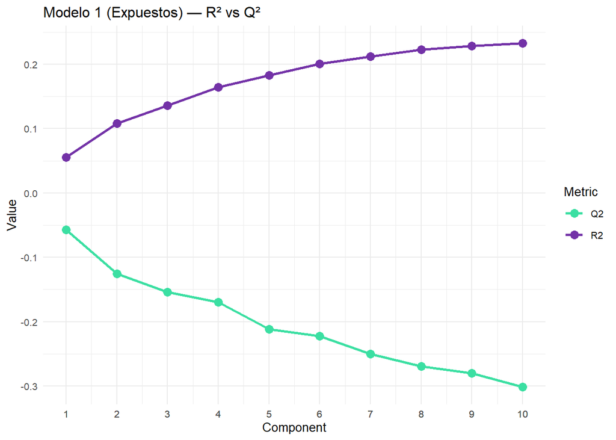

```r
plsPlot(modelo1_exposed, type = "R2vsQ2") +
  ggtitle("Modelo 1 (Expuestos) — R² vs Q²")
```

#### No expuestos

```r
modelo1_notexposed$summary
```

```
##    comp        R2X    cumR2X        R2Y     cumR2Y         Q2      cumQ2
## 1     1 0.30384400 0.3038440 0.09433577 0.09433577 -0.3816229 -0.3816229
## 2     2 0.14361510 0.4474591 0.14205258 0.23638835 -0.1771060 -0.5587289
## 3     3 0.16680745 0.6142666 0.05307679 0.28946514 -0.1959512 -0.7546800
## 4     4 0.11456075 0.7288273 0.04747656 0.33694170 -0.2379486 -0.9926286
## 5     5 0.07579239 0.8046197 0.06012903 0.39707073 -0.3905076 -1.3831363
## 6     6 0.03223442 0.8368541 0.06743089 0.46450162 -0.4522035 -1.8353397
## 7     7 0.06730616 0.9041603 0.02459102 0.48909264 -0.4789694 -2.3143091
## 8     8 0.03123025 0.9353905 0.03933863 0.52843127 -0.6862174 -3.0005265
## 9     9 0.03049091 0.9658814 0.01311361 0.54154488 -0.8298948 -3.8304213
## 10   10 0.02411391 0.9899953 0.01171547 0.55326035 -0.7162258 -4.5466471
##        RMSE
## 1  1.142925
## 2  1.214613
## 3  1.289129
## 4  1.373764
## 5  1.500464
## 6  1.635874
## 7  1.765264
## 8  1.936475
## 9  2.113844
## 10 2.276320
```

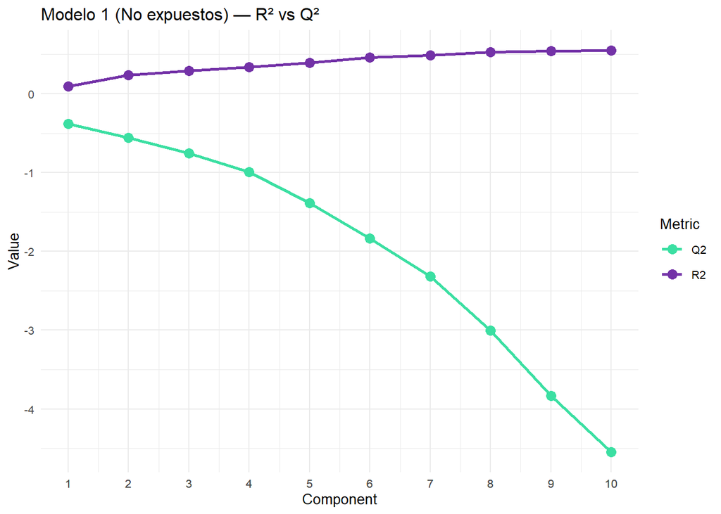

```r
plsPlot(modelo1_notexposed, type = "R2vsQ2") +
  ggtitle("Modelo 1 (No expuestos) — R² vs Q²")
```

#### Reajuste con el nº de componentes definitivo

```r
ncomp_model1_exposed    <- 4
ncomp_model1_notexposed <- 2

set.seed(123)
modelo1_exposed <- pls(
  x = X_exposed_model1, y = Y_exposed_model1, ncomp = ncomp_model1_exposed,
  cvFolds = 5, rep = 10, perm = 100,
  scaling = "standard", scalingY = "standard",
  algo = "nipals", train = 1, parallel = FALSE
)
```

[output not shown]

[output not shown]

```r
set.seed(123)
modelo1_notexposed <- pls(
  x = X_notexposed_model1, y = Y_notexposed_model1, ncomp = ncomp_model1_notexposed,
  cvFolds = 5, rep = 10, perm = 100,
  scaling = "standard", scalingY = "standard",
  algo = "nipals", train = 1, parallel = FALSE
)
```

[output not shown]

**Expuestos** (`ncomp = 4`)

```r
modelo1_exposed$summary
```

```
##   comp       R2X    cumR2X        R2Y     cumR2Y          Q2       cumQ2
## 1    1 0.2231986 0.2231986 0.05530874 0.05530874 -0.05685495 -0.05685495
## 2    2 0.1319133 0.3551119 0.05256885 0.10787758 -0.06894144 -0.12579639
## 3    3 0.1357528 0.4908648 0.02823088 0.13610846 -0.02847578 -0.15427218
## 4    4 0.1223985 0.6132633 0.02839732 0.16450578 -0.01522726 -0.16949943
##       RMSE
## 1 1.018261
## 2 1.050908
## 3 1.064134
## 4 1.070998
```

**No expuestos** (`ncomp = 2`)

```r
modelo1_notexposed$summary
```

```
##   comp       R2X    cumR2X        R2Y     cumR2Y         Q2      cumQ2     RMSE
## 1    1 0.3038440 0.3038440 0.09433577 0.09433577 -0.3816229 -0.3816229 1.142925
## 2    2 0.1436151 0.4474591 0.14205258 0.23638835 -0.1771060 -0.5587289 1.214613
```

### 1.5.3 Gráficos exploratorios por subgrupo

Coloreados solo por tiempo, ya que cada modelo contiene un único nivel de exposición.

#### Expuestos

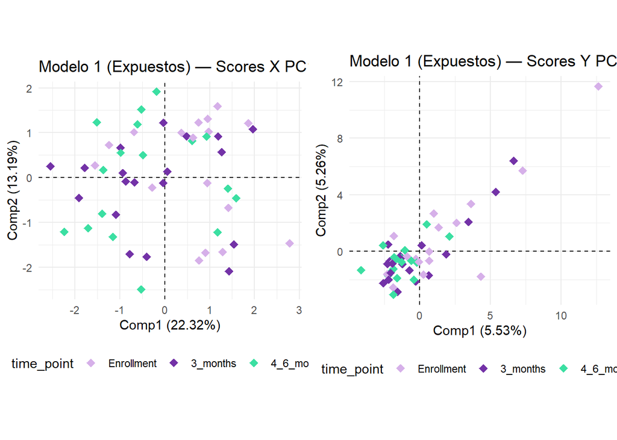

```r
covar_time_exposed_model1 <- factor(species_exposed_model1$time_point,
                                     levels = c("Enrollment", "3_months", "4_6_months"))

p1_exposed <- plsPlot(modelo1_exposed, type = "scoresX", comp = 1:2,
                       colBy = data.frame(time_point = covar_time_exposed_model1),
                       labels = FALSE, ellipses = FALSE) +
  ggtitle("Modelo 1 (Expuestos) — Scores X PC1-PC2 por tiempo")

p2_exposed <- plsPlot(modelo1_exposed, type = "scoresY", comp = 1:2,
                       colBy = data.frame(time_point = covar_time_exposed_model1),
                       labels = FALSE, ellipses = FALSE) +
  ggtitle("Modelo 1 (Expuestos) — Scores Y PC1-PC2 por tiempo")

grid.arrange(p1_exposed, p2_exposed, ncol = 2)
```

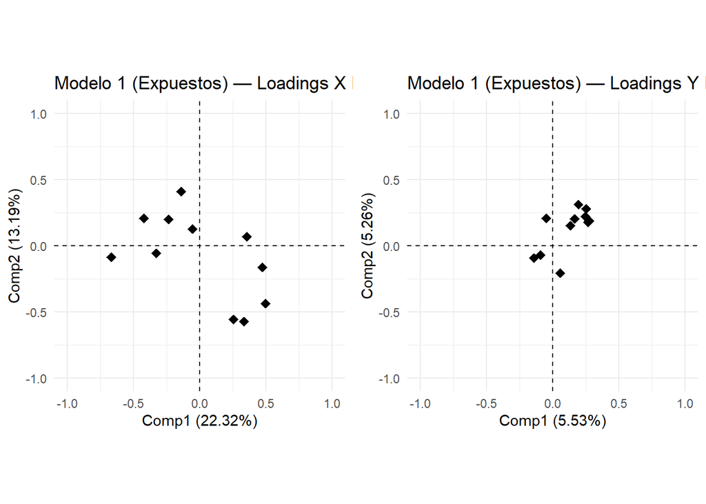

```r
p_loadX_exposed <- plsPlot(modelo1_exposed, type = "loadingsX", comp = 1:2, shape = "point", labels = FALSE, repel = TRUE) +
  ggtitle("Modelo 1 (Expuestos) — Loadings X PC1-PC2")
p_loadY_exposed <- plsPlot(modelo1_exposed, type = "loadingsY", comp = 1:2, shape = "point", labels = FALSE, repel = TRUE) +
  ggtitle("Modelo 1 (Expuestos) — Loadings Y PC1-PC2")
grid.arrange(p_loadX_exposed, p_loadY_exposed, ncol = 2)
```

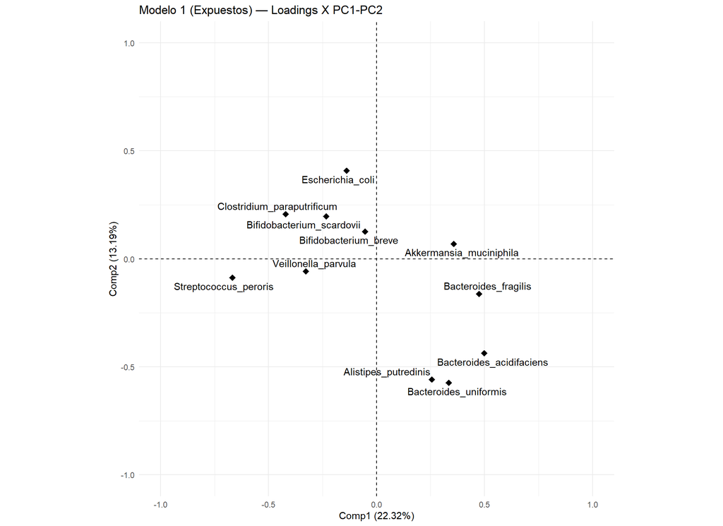

```r
plsPlot(modelo1_exposed, type = "loadingsX", comp = 1:2, shape = "point", labels = TRUE, repel = TRUE) +
  ggtitle("Modelo 1 (Expuestos) — Loadings X PC1-PC2")
```

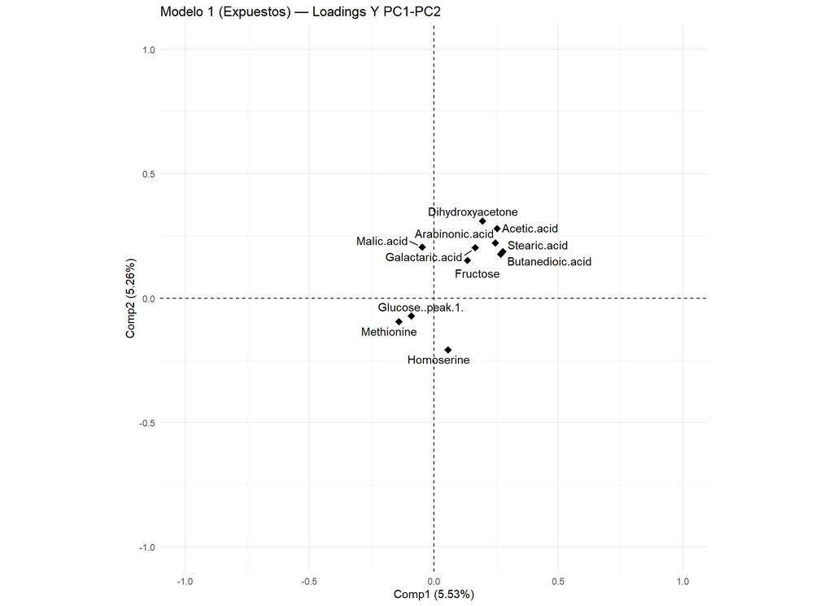

```r
plsPlot(modelo1_exposed, type = "loadingsY", comp = 1:2, shape = "point", labels = TRUE, repel = TRUE) +
  ggtitle("Modelo 1 (Expuestos) — Loadings Y PC1-PC2")
```

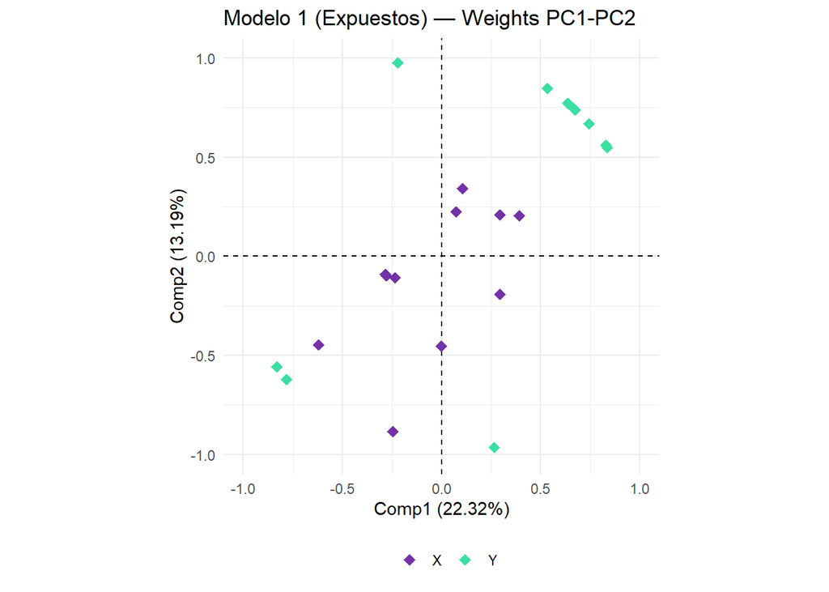

```r
plsPlot(modelo1_exposed, type = "weights", comp = 1:2, labels = FALSE, shape = "point", repel = TRUE) +
  ggtitle("Modelo 1 (Expuestos) — Weights PC1-PC2")
```

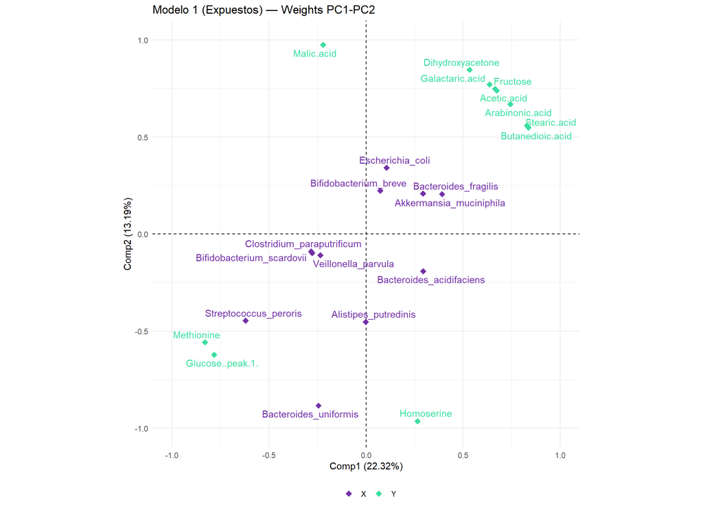

```r
plsPlot(modelo1_exposed, type = "weights", comp = 1:2, labels = TRUE, shape = "point", repel = TRUE) +
  ggtitle("Modelo 1 (Expuestos) — Weights PC1-PC2")
```

#### No expuestos

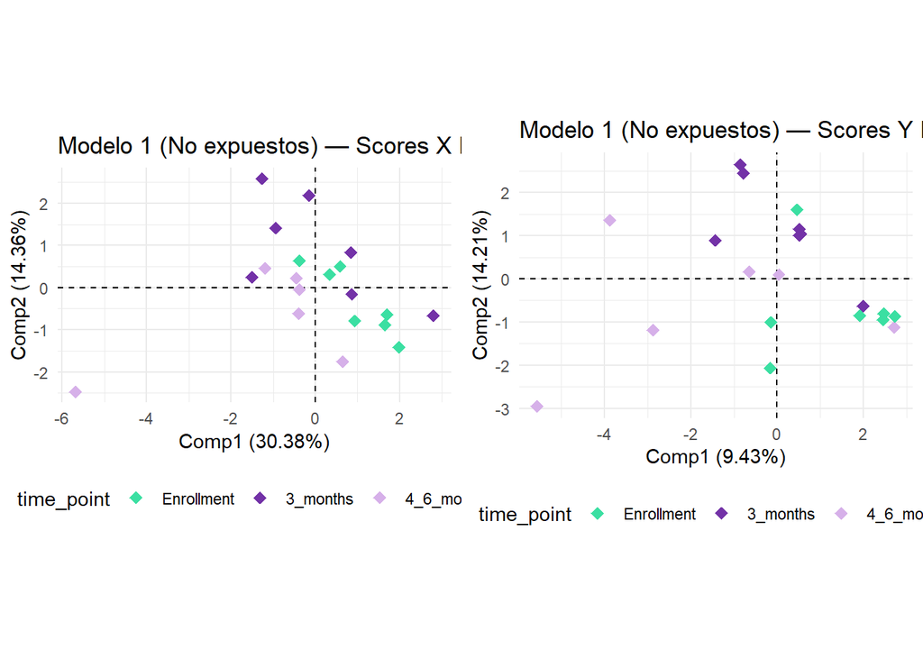

```r
covar_time_notexposed_model1 <- factor(species_notexposed_model1$time_point,
                                        levels = c("Enrollment", "3_months", "4_6_months"))

p1_notexposed <- plsPlot(modelo1_notexposed, type = "scoresX", comp = 1:2,
                          colBy = data.frame(time_point = covar_time_notexposed_model1),
                          labels = FALSE, ellipses = FALSE) +
  ggtitle("Modelo 1 (No expuestos) — Scores X PC1-PC2 por tiempo")

p2_notexposed <- plsPlot(modelo1_notexposed, type = "scoresY", comp = 1:2,
                          colBy = data.frame(time_point = covar_time_notexposed_model1),
                          labels = FALSE, ellipses = FALSE) +
  ggtitle("Modelo 1 (No expuestos) — Scores Y PC1-PC2 por tiempo")

grid.arrange(p1_notexposed, p2_notexposed, ncol = 2)
```

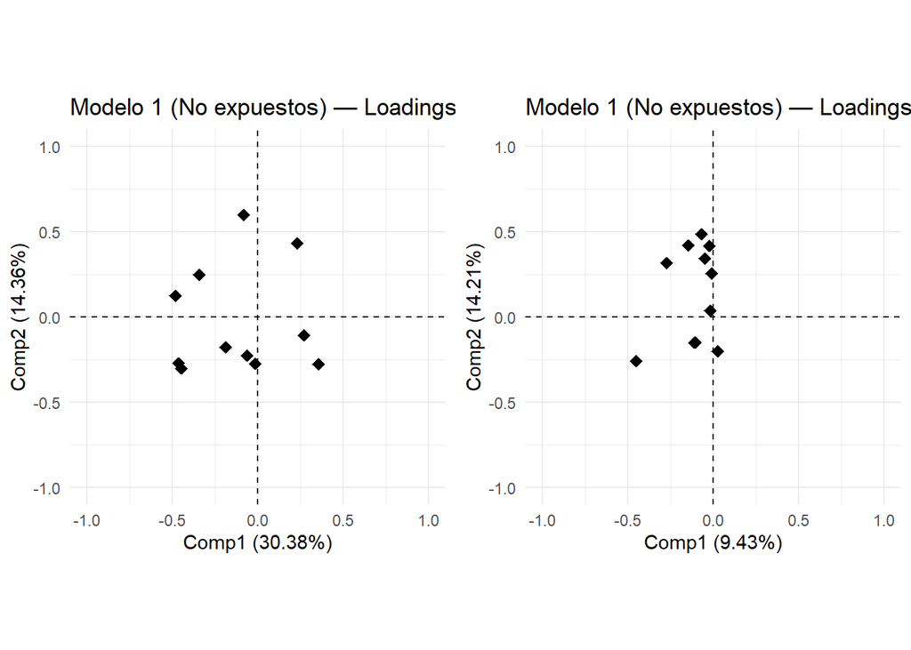

```r
p_loadX_notexposed <- plsPlot(modelo1_notexposed, type = "loadingsX", comp = 1:2, shape = "point", labels = FALSE, repel = TRUE) +
  ggtitle("Modelo 1 (No expuestos) — Loadings X PC1-PC2")
p_loadY_notexposed <- plsPlot(modelo1_notexposed, type = "loadingsY", comp = 1:2, shape = "point", labels = FALSE, repel = TRUE) +
  ggtitle("Modelo 1 (No expuestos) — Loadings Y PC1-PC2")
grid.arrange(p_loadX_notexposed, p_loadY_notexposed, ncol = 2)
```

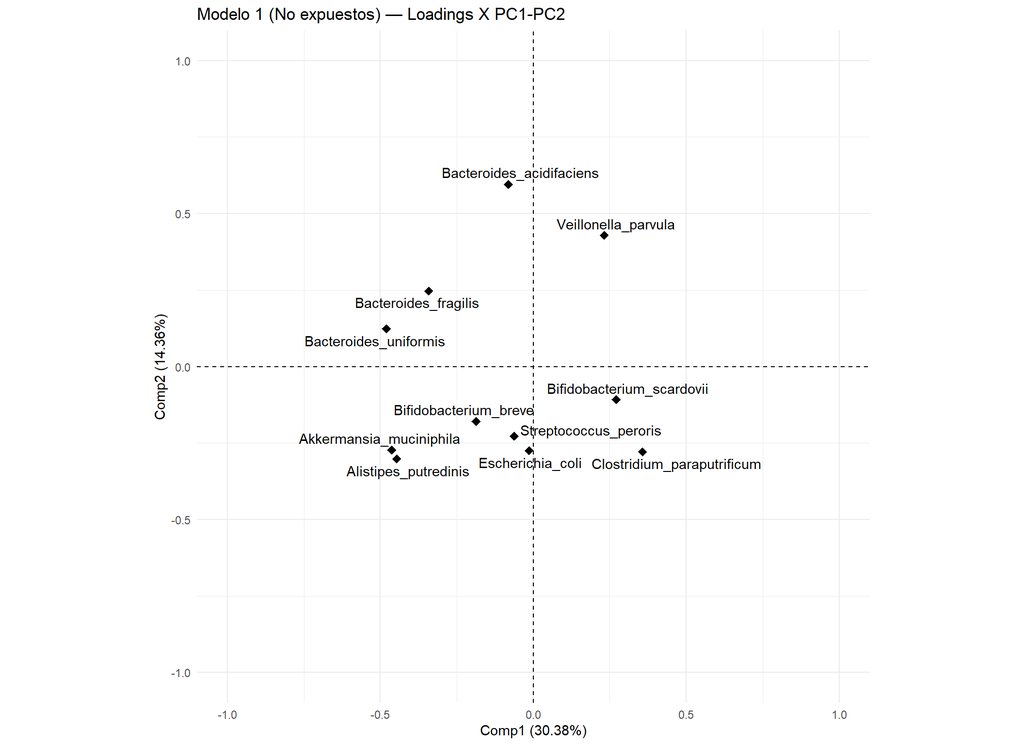

```r
plsPlot(modelo1_notexposed, type = "loadingsX", comp = 1:2, shape = "point", labels = TRUE, repel = TRUE) +
  ggtitle("Modelo 1 (No expuestos) — Loadings X PC1-PC2")
```